# Stat528_Group1_Project

Group1

November 15, 2018

# 1 Project Overview

For our group assignment, we have chose to look at a data set from an Animal Shelter’s in Dallas, TX. Animal shelters help animals find new homes and maintain a safe city. We believe this report can be used to help this shelter save money and operate more efficiently. In addition, this data set can be used in various ways such as marketing, keeping appropriate inventory of pet supplies on hand, and staffing necessary resources at certain times.

The Dallas Animal Shelter data set can be found on the [TidyTuesday](https://github.com/rfordatascience/tidytuesday) project website at the following link: week18_dallas_animals.xlsx

Each data point represents a different animal that entered the shelter identified by an `andimal_id`. Each observation includes the type of animal, the breed of the animal, the `intake_type`, the `outcome_type`, and dates of these events. In addition, there is information about what condition the animal was in at the time of intake and at the time of the outcome.

Our intentions with this data set is to answer a multitude of different questions that could help the animal shelter in the future. We think the following questions can help the animal shelter optimize a plan for incoming pets and try to maximize the opportunity for a pet to get adopted:

- Is there any spikes for adoptions and intake? And can we link them to any reasons?
- How long are animals typically at the shelter? How long for different outcomes?
- Which dog breeds are most likely to be adopted?
- Which dog breed is adopted the quickest?

# 2 Data Description

To read in this data, we have downloaded the file from the above link and created a project to easily read in the file. This `R-Markdown` is part of a package. If you unzip and open the package, you should be able to run this code easily. One thing to note, the following packages were used to create this report and you will need to `install.packages` before running the code:

- `readxl` - to read in excel files.
- `scales` - for adjusting graphics legends and axes.
- `lubridate` - fast and user friendly way to work with dates.
- `rvest` - for scraping information off of the web.
- `RColorBrewer` - for changing graph colors
- `tidyverse` - a collection of packages to manipulate and graph data.

To get started, we will walk you through our analysis process. One thing we noticed immediately with this data set was that there were two tabs on the Excel sheet. The first tab was labeled `raw`, while the second was labeled `simple`. To ensure we had all the data possible we did a quick comparison of the two data sets by `left_joining` the `raw` tab’s column names to the `simple` tab’s column names and making sure there was no `NA` values. We then ensured the lengths of each tab were the same using `nrow`.

```
##      colname_simple      colname_raw
## 1         animal_id        animal_id
## 2       animal_type      animal_type
## 3      animal_breed     animal_breed
## 4             month            month
## 5              year             year
## 6      census_tract     census_tract
## 7  council_district council_district
## 8       intake_type      intake_type
## 9       intake_date      intake_date
## 10     outcome_type     outcome_type
## 11     outcome_date     outcome_date
## 12      chip_status      chip_status
## 13    animal_origin    animal_origin
```

```
## [1] TRUE
```

This proved that the `simple` tab is just a subset of the `raw` tab. Since the `raw` data is not overly large, we will just use the `raw` tab and filter out columns that really won’t help us. This way we will avoid missing any conclusions that can be drawn from the `raw` tab information that cannot be drawn from the `simple` tab. Below is a `glimpse` of the Dallas Animal Shelter columns which seemed potentially meaningful form the `raw` tab.

```
## Observations: 34,819
## Variables: 22
## $ animal_id              <chr> "A0979593", "A0743013", "A1004433", "A0...
## $ animal_type            <chr> "DOG", "DOG", "BIRD", "DOG", "DOG", "DO...
## $ animal_breed           <chr> "RHOD RIDGEBACK", "YORKSHIRE TERR", "CH...
## $ kennel_number          <chr> "FREEZER", "RECEIVING", "BAY 31", "DC 1...
## $ council_district       <chr> "2", "11", "3", "2", "4", "1", "1", "4"...
## $ intake_type            <chr> "CONFISCATED", "STRAY", "STRAY", "STRAY...
## $ intake_subtype         <chr> "QUARANTINE - DEAD ON ARRIVAL", "POSSIB...
## $ reason                 <chr> NA, NA, NA, NA, NA, NA, NA, NA, NA, NA,...
## $ staff_id               <chr> "AS", "HILLMON", "SC", "MMORALES", "SR/...
## $ intake_date            <dttm> 2017-02-20, 2016-11-19, 2017-08-07, 20...
## $ intake_time            <dttm> NA, 1899-12-31 18:00:00, NA, 1899-12-3...
## $ due_out                <dttm> 2017-02-20, 2016-11-29, 2017-08-11, 20...
## $ intake_condition       <chr> "UNHEALTHY UNTREATABLE NON-CONTAGIOUS",...
## $ hold_request           <chr> "RABIES SPECIMEN", NA, NA, NA, "EVERYDA...
## $ outcome_type           <chr> "DEAD ON ARRIVAL", "RETURNED TO OWNER",...
## $ outcome_date           <dttm> 2017-02-21, 2016-11-19, 2017-08-08, 20...
## $ outcome_time           <dttm> NA, NA, NA, 1899-12-31 09:00:00, 1899-...
## $ outcome_condition      <chr> "UNHEALTHY UNTREATABLE NON-CONTAGIOUS",...
## $ animal_origin          <chr> "FIELD", "FIELD", "FIELD", "FIELD", "OV...
## $ additional_information <chr> NA, NA, NA, "ADOPT PENDING SX 12-20-16"...
## $ month                  <chr> "FEB", "NOV", "AUG", "DEC", "FEB", "OCT...
## $ year                   <dbl> 2017, 2016, 2017, 2016, 2017, 2016, 201...
```

# 3 Data Manipulations

Below is a list of manipulations done in order for better analysis of the data:

- We added `intake_day` and `outcome_day` which represents the day of the week when the intake or outcome happened, respectively. This will allow us to draw insight to activity on different days of the week.
- We added `total_time` which represents the number or days of the animal was at the shelter.
- We lumped the 20% least common types of dog breeds brought into the Dallas Animal Shelter as `OTHER`. During the analysis of this report, we discovered there were many different types of dog breeds brought into the shelter and many instance where there was only one or two dogs of that particular dog breed type which was brought into the shelter. Lumping the least common dog breeds into one breed type `OTHER` allows for better visual analysis of dog breeds. To do this we used the following steps:
- Counted dogs by breed type.
- Arranged the breeds in descending order by count.
- Added a column which gave the percent of total dogs.
- Added a column which gave a cumulative percent of that percent column
- Added a `new_breed` column which kept the original breed type of any animal under the 80% point of the cumulative percent column.

# 4 Analysis

In our analysis, we broke in down in three different “events”. Intake, Time at Shelter, and Outcome. These sections represent the flow of an animal coming into the shelter, the time at the shelter, and then leaving the shelter.

## 4.1 Intake

There is **34,819** animals which the Dallas Animal Shelter has taken in. As you can see from the `Intake Time Series` graph below, there is about a years worth of data. The `Intake Time Series` graph also shows that the data from the Dallas Animal Shelter could have some seasonality. The smoothing line dips in the winter months and then spikes in the spring and summer months. However, one years worth of data is not really sufficient for identifying seasonality.

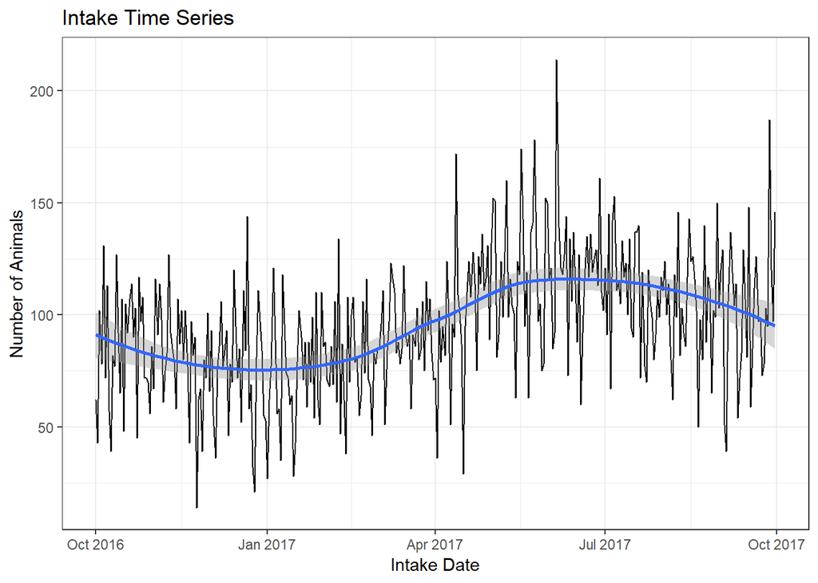

Intake Time Series

The next thing we will look at is why animals are being administered to the Dallas Animal Shelter. The graph below shows different `intake_types` ordered from most common `intake_type` to least common. We can see that `Stray` and `Owner Surrender` are the highest on the list. This is expected. While there are going to be a few lost dogs and a few owners who surrender their dogs because of a conflict, most of them are likely to be found on the street.

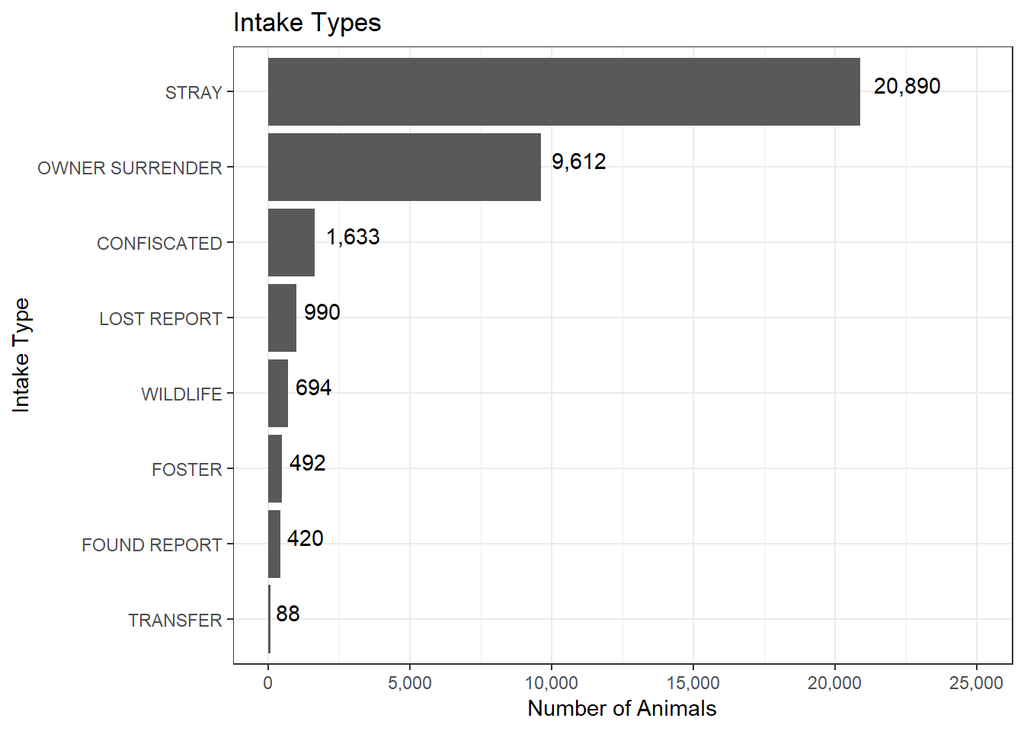

Intake Types

To look closer at these predominate intake types, we can take the column we added earlier, `intake_day`, which gives the day of the week of the `intake_date` and `filter` down to intake types equal to `STRAY` or `OWNER SURRENDER`. We can then make a graph to see if there are days of the week where an owner is more likely to surrender their pet or if it is more likely someone will call in or catch a stray.

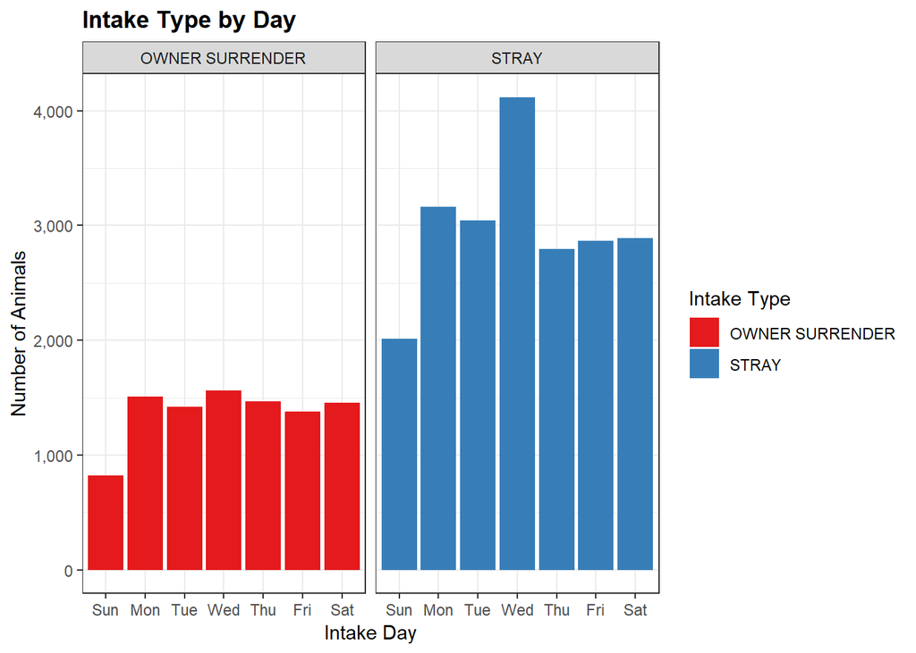

Intake Type by Day

There are a couple things we can identify from the `Intake Type by Day` graph. One is that intake’s are slow on Sundays. After reviewing the [Dallas Animal Shelter](https://dallascityhall.com/departments/dallas-animal-services/Pages/default.aspx)* hours online, the hours are shorter on Sunday. However, they are reasonable considering not many people work on Sunday (assuming I am looking at the right shelter). Another interesting, but unexplainable, conclusion that can be drawn from this graph, is that there is a larger number or strays found on Wednesdays.

*Caution: the animals are really cute on the above link!

Lastly, and probably most obvious while analyzing intake, we will look at what types of animals the Dallas Animal Shelter is taking in.

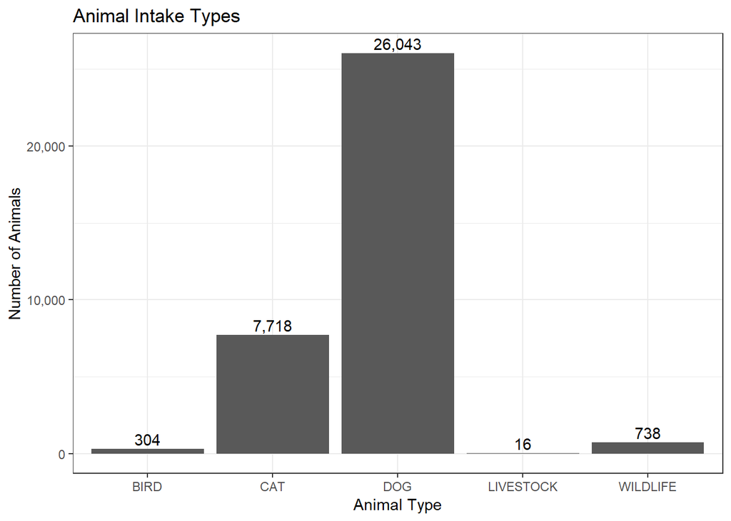

Animal Intake Types

As expected, there are way more dogs than anything else. Because of the large percentage of dogs relative to every other animal types, it will be worth taking a closer look at dogs specifically. The below `Count of Dog Breeds` graph represents the number of each type of dog breed brought into the shelter.

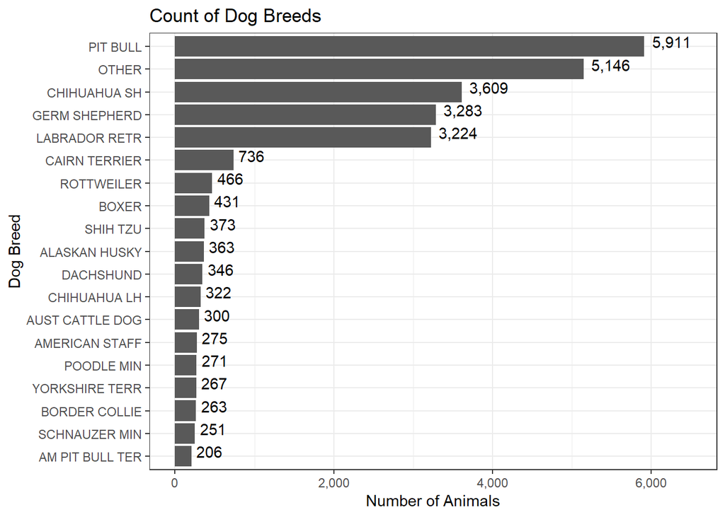

Count of Dog Breeds

From there we can create a graphic which tells us the how the different types of dog breeds came into the shelter. To focus our analysis, we will `filter` down to the two most common intake types, `STRAY` and `OWNER SURRENDER`. Also, to put everything on the same scale we used the percent of dog breeds by `intake_type`. The graph below, `Dog Breed by Intake Types`, has the potential to show us what types of animals most commonly are surrendered by owner. Thankfully for humanity, but unfortunately for this graph, there is a large percent of each dog breed type that are brought in as strays. However, the `Dog Breed by Intake Types` graph does pull out some insight to what dog breeds that might be a little more difficult to deal with and are more likely to be brought in by the owner.

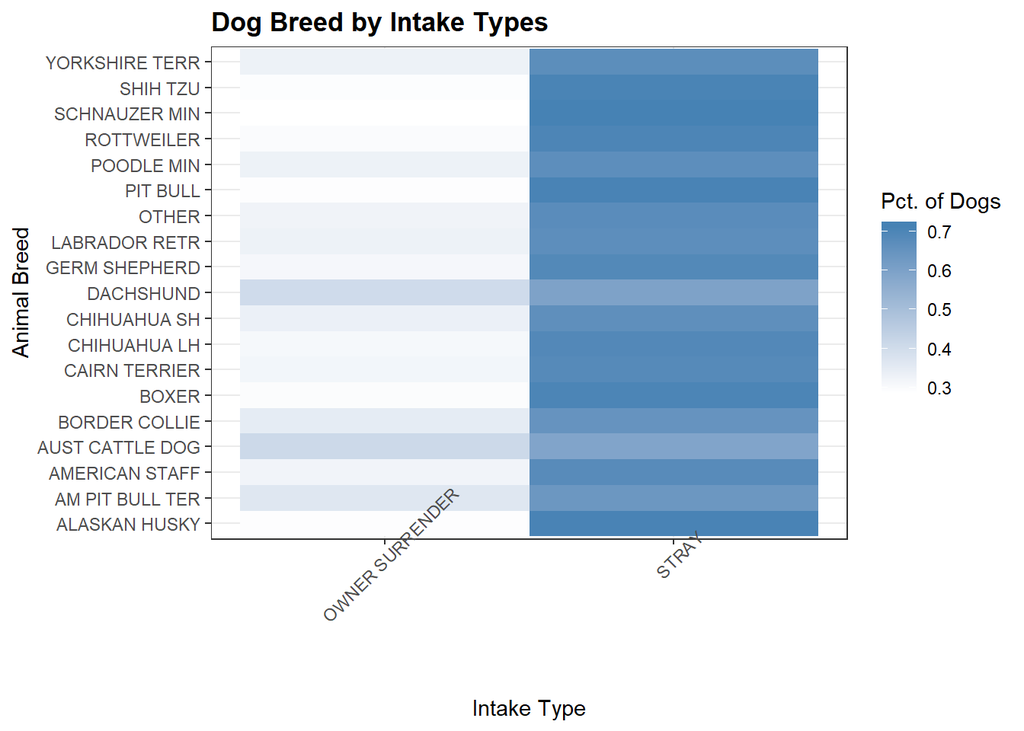

Dog Breed by Intake Types

## 4.2 Time at Shelter

For this section, we will look at the time animals spend at the shelter. An animal shelter obviously houses animals, but sadly, only has room for so many animals. To understand how long animals are in the shelter, we will use the variable we added in the beginning called `total_time` which indicates how many days the animal was in the shelter by using `datediff` on `intake_date` and `outcome_date`. We found that average amount of time an animal spends at the Dallas Animal Shelter is 6.27 days and the time average amount of time that a dog is there before being adopted is is 8.30 days. The table below shows average time at the animal shelter for different `outcome_types`. We can see that if there is an issue with a report, the animal will likely be there a longer time. It is interesting that there are outcome types with reporting issues and makes one wonder what actually physically happens to these animals.

```
##         outcome_type   avg_time
## 1        LOST REPORT 12.72 days
## 2       FOUND REPORT 12.38 days
## 3            MISSING 11.43 days
## 4           ADOPTION  8.33 days
## 5           TRANSFER  6.67 days
## 6             FOSTER  6.01 days
## 7         EUTHANIZED  4.59 days
## 8               DIED  3.82 days
## 9  RETURNED TO OWNER  2.75 days
## 10   DEAD ON ARRIVAL  1.48 days
## 11          WILDLIFE  0.56 days
```

Next, we looked at the two most interesting and important outcomes, `ADOPTION` and `EUTHANIZED` in the `Histogram of Time at Shelter by Top Outcomes` graph. As you can see, the time spent at the Dallas Animal Shelter is usually not that long and extremely right skewed. However, the graphs align with our previous findings that animal spends about 6.27 at the shelter.

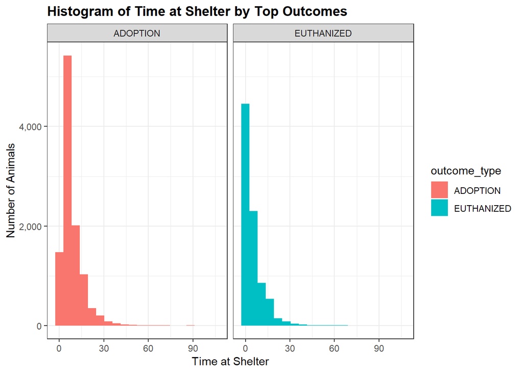

Histogram of Time at Shelter by Top Outcomes

To bring the focus more to dogs again, the below `Average Time at Shelter Before Adoption` graph represents the average number of days that a particular dog breed spends at the Dallas Animal Shelter before it is adopted. While this animal shelter’s data set does not have “animal size”, but from basic knowledge of dog size, we can see that smaller dogs are adopted more quickly.

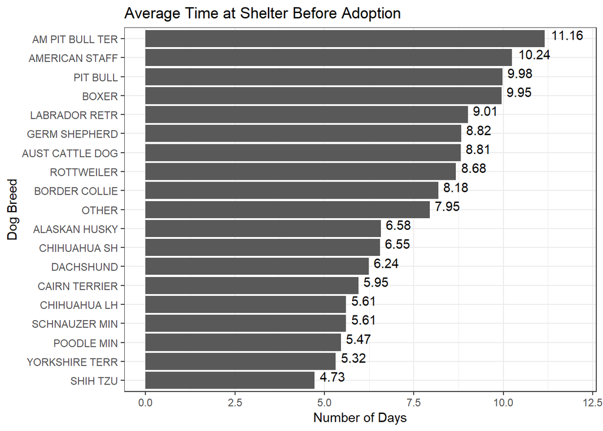

Average Time at Shelter Before Adoption

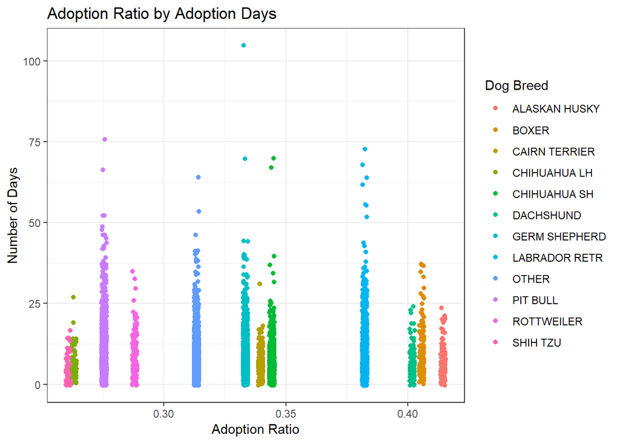

Adoption Ratio by Adoption Days

## 4.3 Outcome

Next we will do the same type of time series analysis on the `outcome_date` as we did on the `income_date`. The `Outcome Time Series` graph below shows the same seasonality as our intake data, the smoothing line dips in the winter months and then spikes in the spring and summer months. While it is not as drastic of a sign for seasonality, this is not surprising since when it is warm out we want to be outside and walk with dogs, while some people could look at an animal being a burden in the winter time.

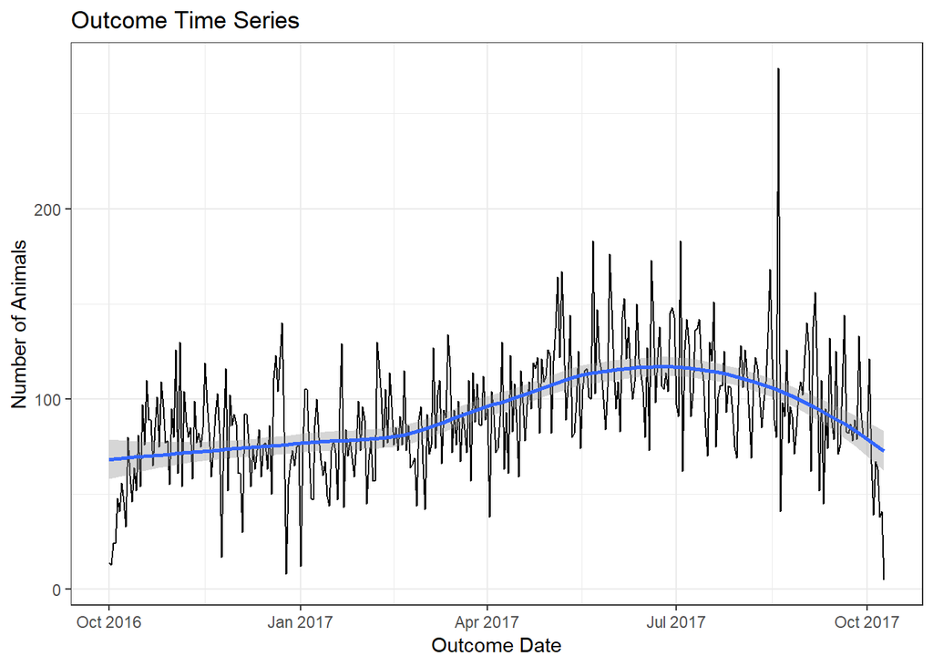

Outcome Time Series

Similar to our `Intake Time Series` graph, the `Outcome Time Series` graph has large spikes from day to day. We wanted to see if there was any effects of holidays on adoption. To do this, we used a federal holiday data set from [Kaggle](https://www.kaggle.com/gsnehaa21/federal-holidays-usa-19662020) and plotted them as vertical lines on our time series graph. From the below graph, `Adoption Around Holidays`, we can see that there are large spikes right after Thanksgiving and right before Christmas. This is expected after Thanksgiving because adoption centers usually have some sort of black Friday promotion and a puppy is obviously the perfect Christmas gift. I know I want one!

The other big spike before Labor Day is somewhat unexplained. Our guess is that they had some sort of big promotion. I am pretty sure the humane society in my town does a promotion for free or $1 dogs at some point in the summer.

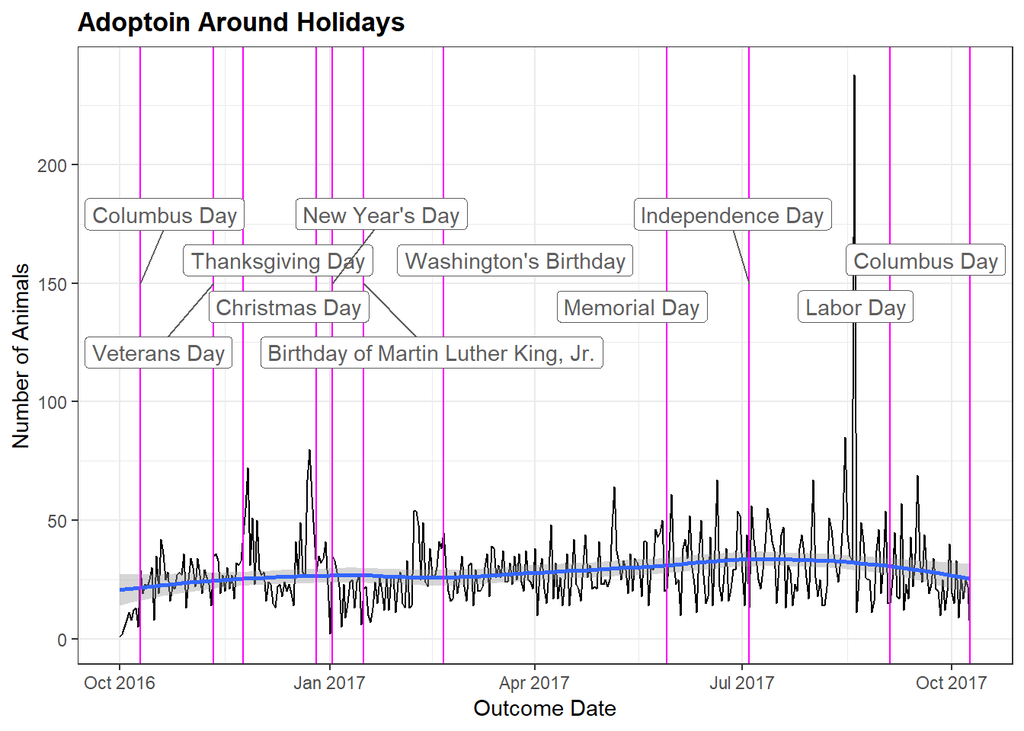

Adoptoin Around Holidays

Moving on, the `Outcome Types` graph below represents the `outcome_types` of animals from the Dallas Animal Shelter ordered from most common `outcome_types` to least common. We can see that `ADOPTION`, `EUTHENIZED`, and `TRANSFER` are the most common. `ADOPTION` and `EUTHENIZED` are expected to be the most common because that is the purpose of an animal shelter.

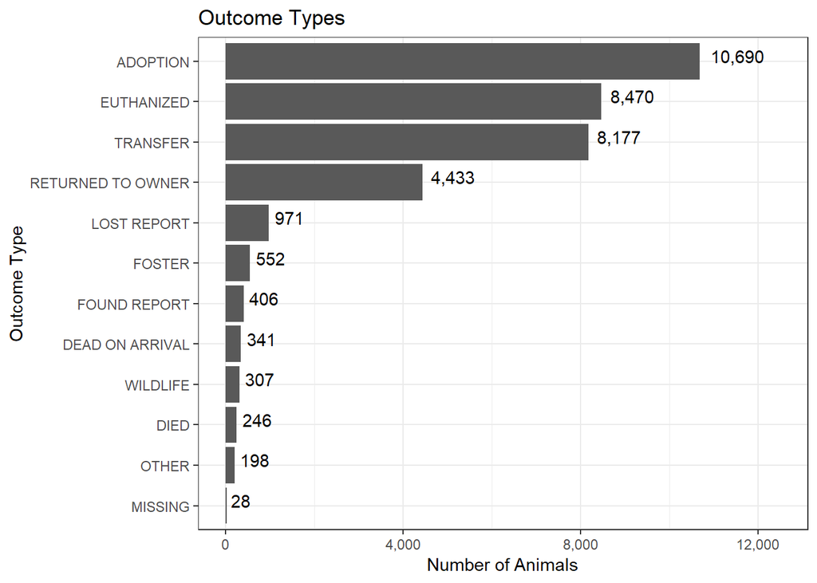

Outcome Types

Like we did in our `Dog Breed Intake Types` graph, we looked at percent of dog breeds by `outcome_type`. The `Dog Breed by Outcome Types` graph gives us insight to what types of animals most commonly are adopted or euthanized. As you can see, there are dog breeds which are more likely to be put down. These dogs are the breeds which someone would stereotype with being aggressive. For example, it is about a 50/50 chance that Pitbull’s and Rottweiler’s will be adopted or euthanized, so it is possible those stereo types are true. However, Pitbulls are the most common animal brought into the shelter so there is a bigger sample and it is possible they have a lesser standard for why they would euthanized.

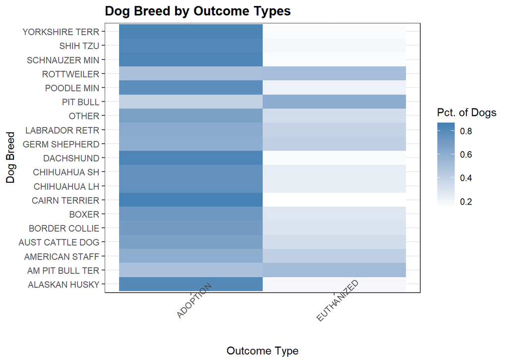

Dog Breed by Outcome Types

To plan accordingly, it will be a good idea to look at the adoption rate on a daily basis. As you can see from the below `Adoption by Day` graph, Saturdays are the busiest days, which is not surprising. Another useful insight which can be seen from this graph is that the beginning of the work week is relatively busy compared to the end of the work week. With this information, we can staff appropriately to speed up the process of customers adopting dogs and possibly increase the number of adoptionn because customers won’t be waiting around deciding whether or not to adopt a dog.

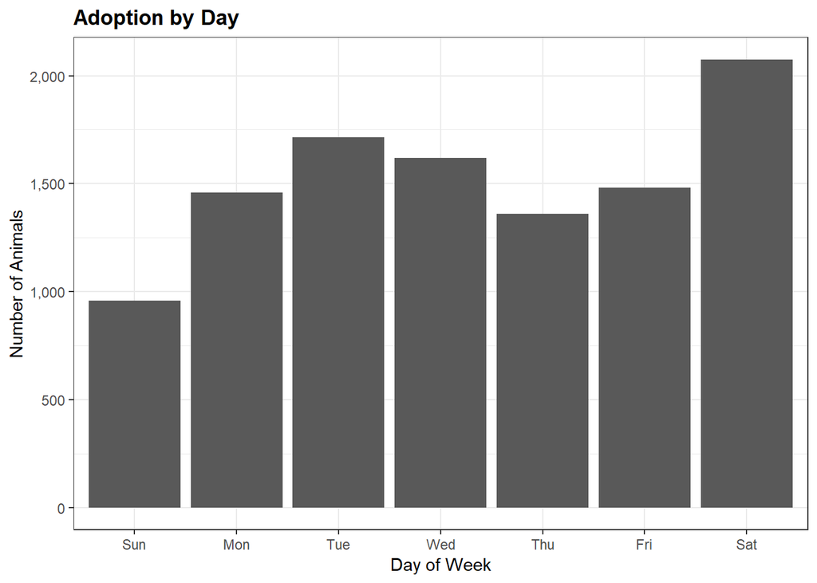

Adoption by Day

# 5 Conclusion

In our analysis when we examined how long animals are at the Dallas Animal Shelter We found that average amount of time an animal spends at the Dallas Animal Shelter is 6.27 days and the time average amount of time that a dog is there before being adopted is is 8.30 days and varys between dog breeds. Overally, we can see that animals are usually adopted withing a week or so, but even shorter amont of time if they are a small dog breed. In addtion to findings about adoption, we found that the Dallas Animal Shelter could possibly have a process or reporting problem which holds dogs up from being adopted.

When looking at the outcome of animals and dogs from the Dallas Animal shelter, we took a closer look at adoption through out the year and tied dates of adoption to holiday’s. We found the dallas animal shelter can expect a lot more adoptions right after Thanksgiving and right before Christmas. We know that animals at the Dallas anmial shelter are likely going to be adopted, euthanized, or transfered and that more agressive dog breeds have a higher probability of being euthanized. In addtion, we know what the beginning of the week and Saturdays are usaully busier at the Dallas Animal Shelter.

# 6 Plans for Further work:

To improve this study, we could look at things such as:

- Review promotions that the Dallas Animal Shelter has by scraping their facebook or twitter.
- Include how dog size relates to adoption by finding a data set with dog size and then cleaninng and standarizing the dog names and joining to our data set.
- When we `glimpsed` at the data you could see there were kennel numbers. If we had enough data we could see if location of animals and adoption rates are related.
- We could break down adoption by month to see if there is busier months than others, or even times to see if the selter is busier at certain times to staff apporpiately.